# Meeting 12 - ANOVA

Matthew E. Aiello-Lammens

2020-04-29

# Introduction to Analysis of Variance - ANOVA

While learning about regression, we’ve been working with both continuous predictor and response variables. But in biology there are many times when we are working with **categorical** predictor variables and continuous responses. For example, let’s consider a fertilizer addition experiment, where the growth of some plant species is measured under a fertilizer versus no-fertilizer treatment. Here, the predictor variable (fertilizer addition or not) is a categorical variable.

#### Challenge

We have worked with this kind of simple case, where we have one-predictor variable which can take two values. What did we do in this case?

```r
library(dplyr)
data(iris)
t.test( x = filter(iris, Species == "setosa")$Petal.Length,
        y = filter(iris, Species == "versicolor")$Petal.Length )
```

```
##
##  Welch Two Sample t-test
##
## data:  filter(iris, Species == "setosa")$Petal.Length and filter(iris, Species == "versicolor")$Petal.Length
## t = -39.493, df = 62.14, p-value < 2.2e-16
## alternative hypothesis: true difference in means is not equal to 0
## 95 percent confidence interval:
##  -2.939618 -2.656382
## sample estimates:
## mean of x mean of y
##     1.462     4.260
```

```r
anova(lm(data = filter(iris, Species != "virginica"), formula = Petal.Length ~ Species))
```

```
## Analysis of Variance Table
##
## Response: Petal.Length
##           Df  Sum Sq Mean Sq F value    Pr(>F)
## Species    1 195.720 195.720  1559.7 < 2.2e-16 ***
## Residuals 98  12.298   0.125
## ---
## Signif. codes:  0 '***' 0.001 '**' 0.01 '*' 0.05 '.' 0.1 ' ' 1
```

If we have more than two values within a single predictor variable, then we cannot use a *t*-test. Here we go to an ANOVA.

```r
anova(lm(data = iris, formula = Petal.Length ~ Species))
```

```
## Analysis of Variance Table
##
## Response: Petal.Length
##            Df Sum Sq Mean Sq F value    Pr(>F)
## Species     2 437.10 218.551  1180.2 < 2.2e-16 ***
## Residuals 147  27.22   0.185
## ---
## Signif. codes:  0 '***' 0.001 '**' 0.01 '*' 0.05 '.' 0.1 ' ' 1
```

## Visual understanding of ANOVA

First, recall the visual understanding of linear regression:

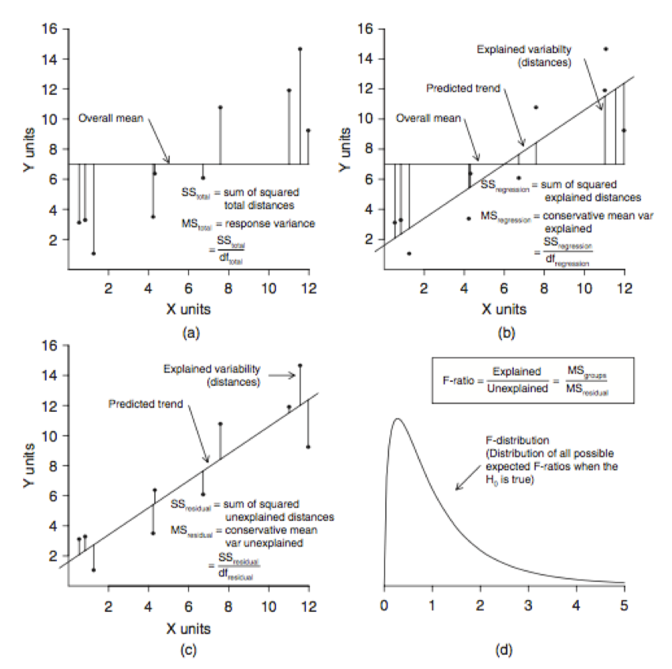

Logan - Figure 8.3

Now, what would this look like if the **x** value (i.e., the predictor) was categorical?

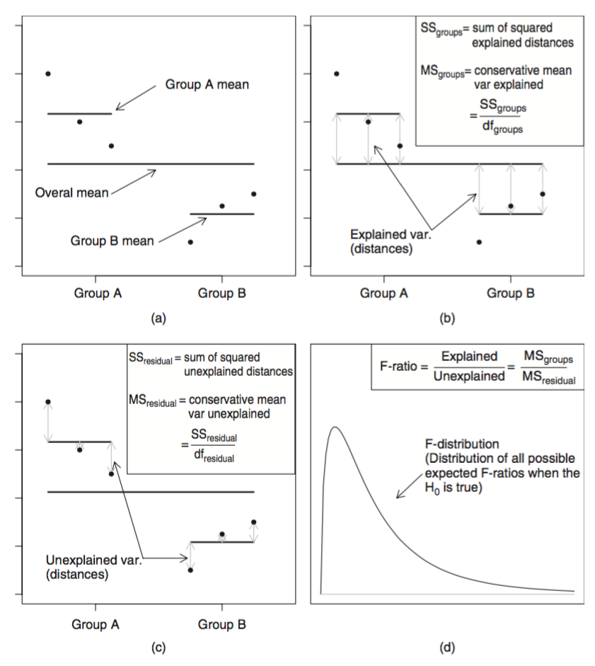

Logan - Figure 10.2

## Fixed versus Random Effects

**Fixed factors** are ones we have manipulated, or that we expect *a priori* to have an effect on the response. From Logan, p 254 - “conclusions about the effects of a fixed factor are restricted to the specific treatment levels investigated …”

**Random factors** are, as per Logan, p. 254, “randomly chosen from all the possible levels of populations and are used as random representatives of the populations”. E.g., density of plants could be random. Or position of camera traps on a hillside.

## Null hypotheses

**Fixed effects model:**

$$H_0: \mu_1 = \mu_2 = ... = \mu_i = \mu$$

**Random effects model:**

$$H_0: \sigma^2_1 = \sigma^2_2 = ... = \sigma^2_i = \sigma^2$$

# One-way ANOVA

From Medley and Clements (1998), by way of Logan 2010 - investigation of the impact of zinc contamination on diversity of diatom species in the USA Rocky Mountains. (From Logan 2010 - Example 10A)

Get the data

```r
diatoms <- read.csv(file = "https://mlammens.github.io/ENS-623-Research-Stats/data/Logan_Examples/Chapter10/Data/medley.csv")
```

Look at the data

```r
head(diatoms)
```

```
##   STREAM ZINC DIVERSITY
## 1  Eagle BACK      2.27
## 2  Eagle HIGH      1.25
## 3  Eagle HIGH      1.15
## 4  Eagle  MED      1.62
## 5   Blue BACK      1.70
## 6   Blue HIGH      0.63
```

Note that species diversity here is measured as the [Shannon’s Diversity Index](https://en.wikipedia.org/wiki/Diversity_index#Shannon_index), which is one of *many* different diversity measurements.

Make a plot - categorical predictor and continuous response -> box plot!

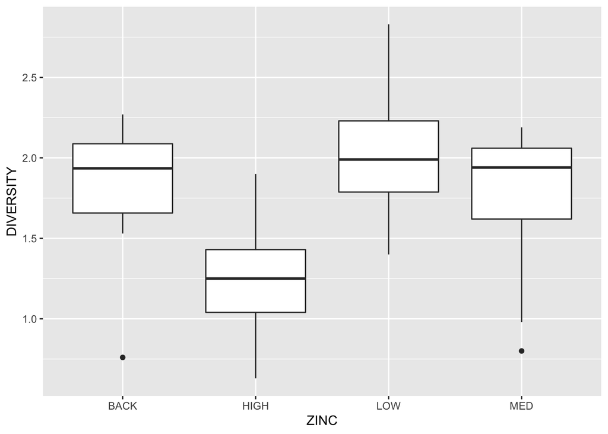

```r
library(ggplot2)

ggplot(data = diatoms, aes(x = ZINC, y = DIVERSITY)) +
  geom_boxplot()
```

Just for fun, here’s another kind of plot we could use. It’s called a violin plot. What do you think it is showing us?

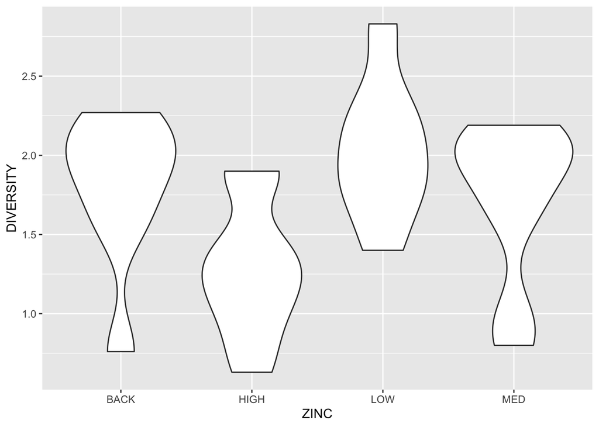

```r
ggplot(data = diatoms, aes(x = ZINC, y = DIVERSITY)) +
  geom_violin()
```

Let’s perform an ANOVA, first using the `aov` function

```r
summary(aov(data = diatoms, DIVERSITY ~ ZINC ))
```

```
##             Df Sum Sq Mean Sq F value Pr(>F)
## ZINC         3  2.567  0.8555   3.939 0.0176 *
## Residuals   30  6.516  0.2172
## ---
## Signif. codes:  0 '***' 0.001 '**' 0.01 '*' 0.05 '.' 0.1 ' ' 1
```

Let’s do this again, but this time using the `lm` function. The same function we used for linear regression!

```r
## Make the linear model
diatom_lm <- lm(data = diatoms, DIVERSITY ~ ZINC )

## Look at the ANOVA results
anova(diatom_lm)
```

```
## Analysis of Variance Table
##
## Response: DIVERSITY
##           Df Sum Sq Mean Sq F value  Pr(>F)
## ZINC       3 2.5666 0.85554  3.9387 0.01756 *
## Residuals 30 6.5164 0.21721
## ---
## Signif. codes:  0 '***' 0.001 '**' 0.01 '*' 0.05 '.' 0.1 ' ' 1
```

```r
## Look at the linear model results
summary(diatom_lm)
```

```
##
## Call:
## lm(formula = DIVERSITY ~ ZINC, data = diatoms)
##
## Residuals:
##      Min       1Q   Median       3Q      Max
## -1.03750 -0.22896  0.07986  0.33222  0.79750
##
## Coefficients:
##             Estimate Std. Error t value Pr(>|t|)
## (Intercept)  1.79750    0.16478  10.909 5.81e-12 ***
## ZINCHIGH    -0.51972    0.22647  -2.295   0.0289 *
## ZINCLOW      0.23500    0.23303   1.008   0.3213
## ZINCMED     -0.07972    0.22647  -0.352   0.7273
## ---
## Signif. codes:  0 '***' 0.001 '**' 0.01 '*' 0.05 '.' 0.1 ' ' 1
##
## Residual standard error: 0.4661 on 30 degrees of freedom
## Multiple R-squared:  0.2826, Adjusted R-squared:  0.2108
## F-statistic: 3.939 on 3 and 30 DF,  p-value: 0.01756
```

**Challenge** Let’s work together to interpret the `summary` output.

We can also look at our model diagnostics

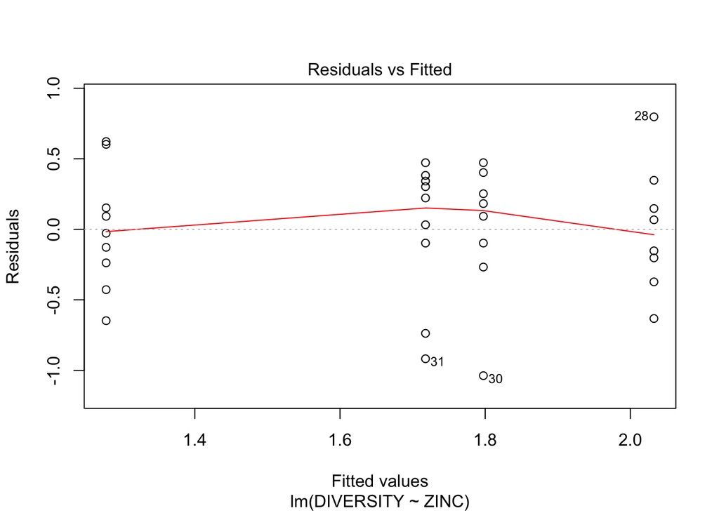

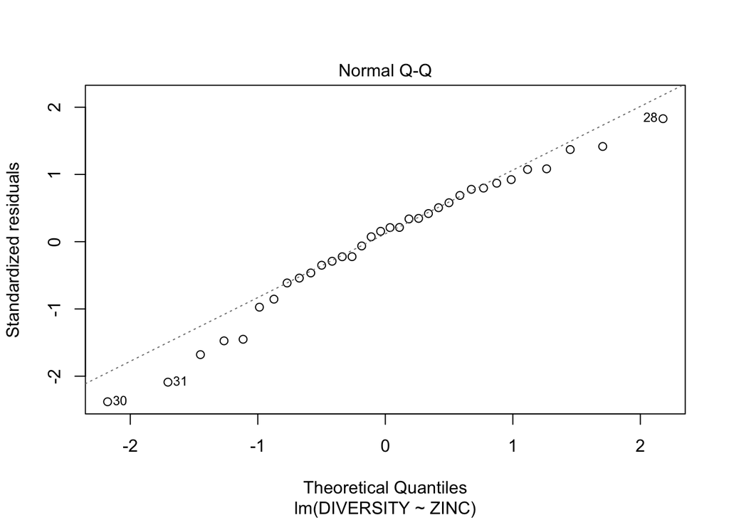

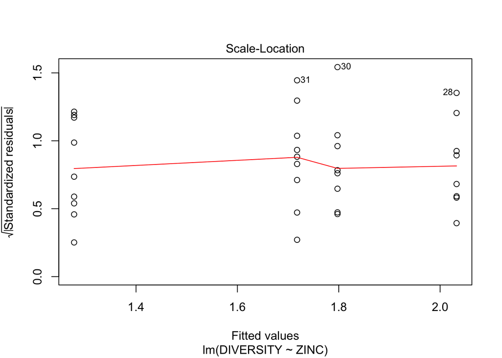

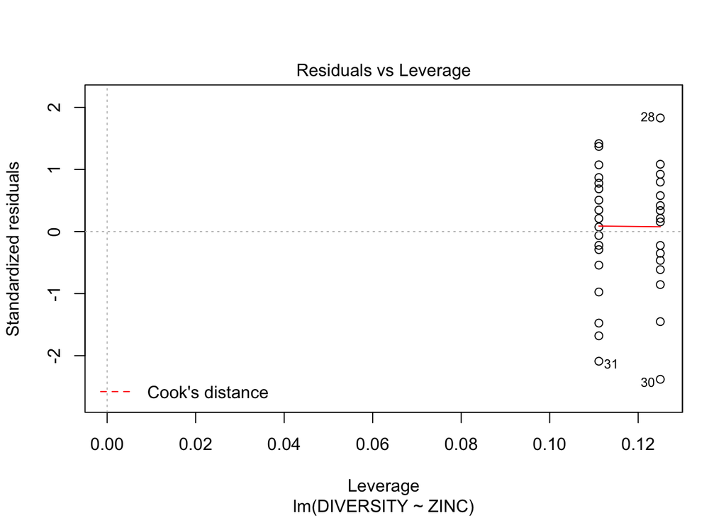

```r
## Look at the model diagnostics
plot(diatom_lm)
```

## Post-hoc comparisons

Now we can say that the biodiversity measures taken at different zinc concentrations **DO NOT** come from a common distribution, but we don’t know which are different from each other.

We could compare each concentration to each of the others separately, but recall the problems with multiple comparisons. Instead, we’ll use a *post-hoc* comparison method. Specifically, we’ll use the Tukey Honest Significant Differences (HSD), but there are several other methods you might use as well (see Logan p. 265).

```r
TukeyHSD(aov(data = diatoms, DIVERSITY ~ ZINC ))
```

```
##   Tukey multiple comparisons of means
##     95% family-wise confidence level
##
## Fit: aov(formula = DIVERSITY ~ ZINC, data = diatoms)
##
## $ZINC
##                  diff        lwr        upr     p adj
## HIGH-BACK -0.51972222 -1.1355064 0.09606192 0.1218677
## LOW-BACK   0.23500000 -0.3986367 0.86863665 0.7457444
## MED-BACK  -0.07972222 -0.6955064 0.53606192 0.9847376
## LOW-HIGH   0.75472222  0.1389381 1.37050636 0.0116543
## MED-HIGH   0.44000000 -0.1573984 1.03739837 0.2095597
## MED-LOW   -0.31472222 -0.9305064 0.30106192 0.5153456
```

Note, that for reasons that have never been clear to me, you can only use the TukeyHSD method when using the `aov` function. For an alternative approach, see the `glht` function in the `multcomp` package. This is described in Logan (e.g., p. 267).

## Planned comparisons

Where as unplanned, i.e. *post-hoc*, comparisons require a correction for multiple comparisons, planned comparisons do not. We will not cover planned comparisons in class, but they may show up in your own work. Example 10B in Logan 2010 provides an example of the use of planned comparisons.

## Non-parametric ANOVA

As with many of the other methods we’ve discussed, there are also non-parametric ANOVA approaches. The most common is the Kruskal-Wallace test, which uses **rank based** statistics.

# Nested ANOVA

Sometimes your replicates aren’t quite independent.

Look how the replicates presented in panel (b) below are *nested* within a bigger treatment block.

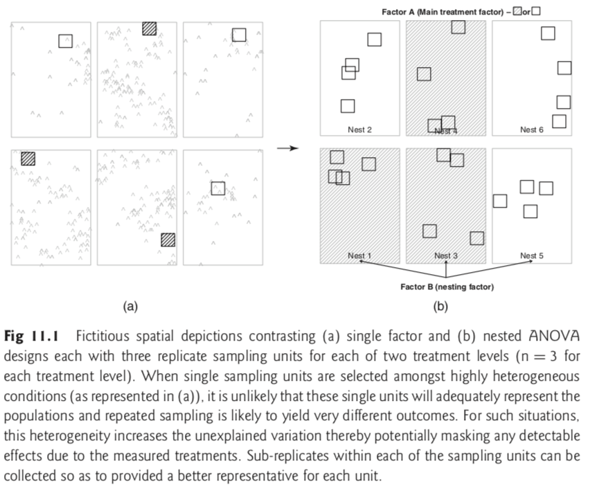

Logan - Figure 11.1

For formula, see Logan p. 284 and for calculation of F-ratios see Table 11.1. **Note that Mean-Squared Errors are the same if B is random or fixed, but F-ratio is different! Why? Discuss.**

## Unbalanced designs

Often your observations will not be clean. This is unfortunate, as it makes the analyses more complicated. But they are still doable.

### Nested ANOVA Example

From Logan Example 11.A - Density-dependent grazing effects of sea urchin on filamentous algae (Andrew and Underwood 1993).

Levels: 1. Sea urchin density 2. Patches of Reef 3. Quadrats within patches

Get the data and have a look.

```r
algae_density <- read.csv(file = "https://mlammens.github.io/ENS-623-Research-Stats/data/Logan_Examples/Chapter11/Data/andrew.csv")

head(algae_density)
```

```
##   TREAT PATCH QUAD ALGAE
## 1    0%     1    1    46
## 2    0%     1    2    44
## 3    0%     1    3    41
## 4    0%     1    4    29
## 5    0%     1    5    11
## 6    0%     2    1    65
```

```r
summary(algae_density)
```

```
##   TREAT        PATCH            QUAD       ALGAE
##  0%  :20   Min.   : 1.00   Min.   :1   Min.   : 0.00
##  100%:20   1st Qu.: 4.75   1st Qu.:2   1st Qu.: 0.00
##  33% :20   Median : 8.50   Median :3   Median : 5.00
##  66% :20   Mean   : 8.50   Mean   :3   Mean   :20.26
##            3rd Qu.:12.25   3rd Qu.:4   3rd Qu.:41.00
##            Max.   :16.00   Max.   :5   Max.   :83.00
```

Patch and Quad need to be converted to factors!

```r
algae_density$PATCH <- factor(algae_density$PATCH)
algae_density$QUAD <- factor(algae_density$QUAD)

summary(algae_density)
```

```
##   TREAT        PATCH    QUAD       ALGAE
##  0%  :20   1      : 5   1:16   Min.   : 0.00
##  100%:20   2      : 5   2:16   1st Qu.: 0.00
##  33% :20   3      : 5   3:16   Median : 5.00
##  66% :20   4      : 5   4:16   Mean   :20.26
##            5      : 5   5:16   3rd Qu.:41.00
##            6      : 5          Max.   :83.00
##            (Other):50
```

Much better.

Let’s make some visuals.

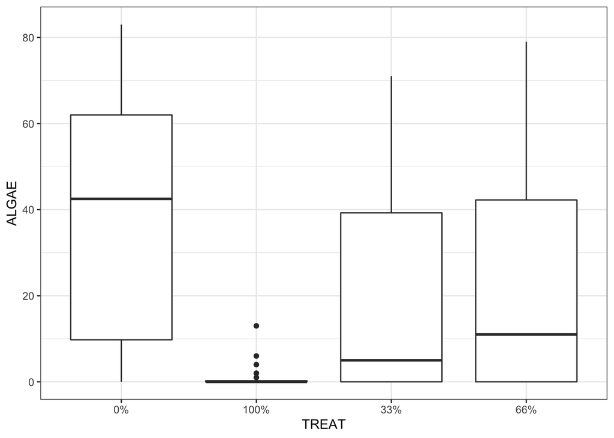

```r
library(ggplot2)

ggplot(data = algae_density) +
  geom_boxplot(aes(x = TREAT, y = ALGAE)) +
  theme_bw()
```

We should also consider this from the perspective to collapsing the quadrats into their mean values.

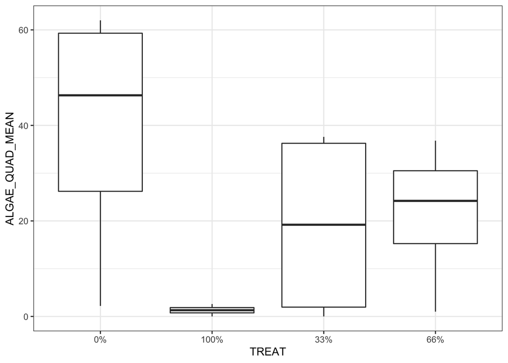

```r
library(dplyr)

algae_density_agg <-
  algae_density %>%
  group_by(TREAT, PATCH) %>%
  summarize(ALGAE_QUAD_MEAN = mean(ALGAE))

ggplot(data = algae_density_agg) +
  geom_boxplot(aes(x = TREAT, y = ALGAE_QUAD_MEAN)) +
  theme_bw()
```

Construct an ANOVA model and look at the results.

```r
algae_density_aov <- aov(data = algae_density, ALGAE ~ TREAT + Error(PATCH))

summary(algae_density_aov)
```

```
##
## Error: PATCH
##           Df Sum Sq Mean Sq F value Pr(>F)
## TREAT      3  14429    4810   2.717 0.0913 .
## Residuals 12  21242    1770
## ---
## Signif. codes:  0 '***' 0.001 '**' 0.01 '*' 0.05 '.' 0.1 ' ' 1
##
## Error: Within
##           Df Sum Sq Mean Sq F value Pr(>F)
## Residuals 64  19110   298.6
```

- What can we conclude?
- What was the unit of replication?

## Factorial ANOVA

What if we want to look at two, or more, factors where one is not nested in the other?

**See visuals as per Logan, Fig 12.1 and 12.2.**

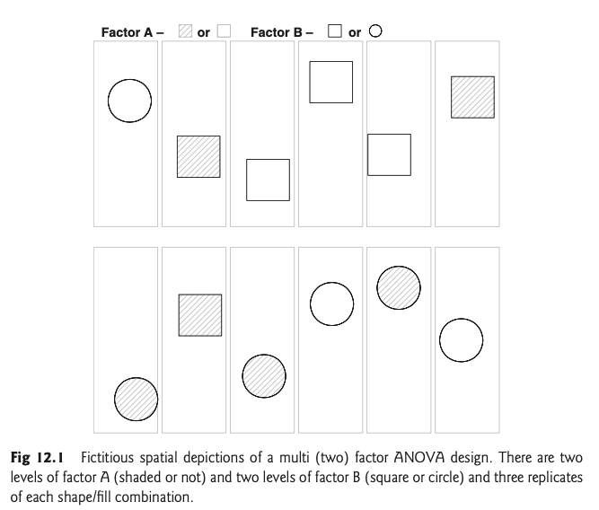

Logan - Figure 12.1

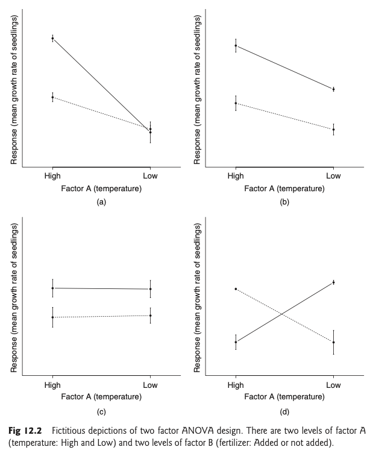

Logan - Figure 12.2

For formula, see Logan p. 314 and for calculation of F-ratios see Table 12.1.

### Example - Two factor fixed effects model (Model I)

From Logan (Example 12A):

> Quinn (1988) manipulated the density of adults limpets within enclosures (8, 15, 30 and 45 individuals per enclosure) during two seasons (winter-spring and summer-autumn) so as to investigate the effects of adult density and season on egg mass production by intertidal limpets. Three replicate enclosures per density/season combination were used, and both density and season were considered fixed factors (from Box 9.4 of Quinn and Keough (2002)).

```r
limpets <- read.csv(file = "https://mlammens.github.io/ENS-623-Research-Stats/data/Logan_Examples/Chapter12/Data/quinn.csv")

head(limpets)
```

```
##   DENSITY SEASON  EGGS
## 1       8 spring 2.875
## 2       8 spring 2.625
## 3       8 spring 1.750
## 4       8 summer 2.125
## 5       8 summer 1.500
## 6       8 summer 1.875
```

```r
summary(limpets)
```

```
##     DENSITY         SEASON        EGGS
##  Min.   : 8.00   spring:12   Min.   :0.3560
##  1st Qu.:13.25   summer:12   1st Qu.:0.9165
##  Median :22.50               Median :1.4330
##  Mean   :24.50               Mean   :1.4717
##  3rd Qu.:33.75               3rd Qu.:1.9227
##  Max.   :45.00               Max.   :2.8750
```

```r
limpets$DENSITY <- factor(limpets$DENSITY)
```

Let’s get some visuals.

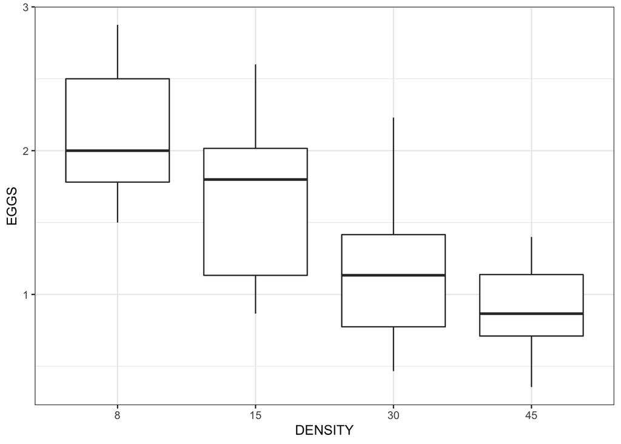

```r
ggplot(data = limpets) +
  geom_boxplot(aes(x = DENSITY, y = EGGS)) +
  theme_bw()
```

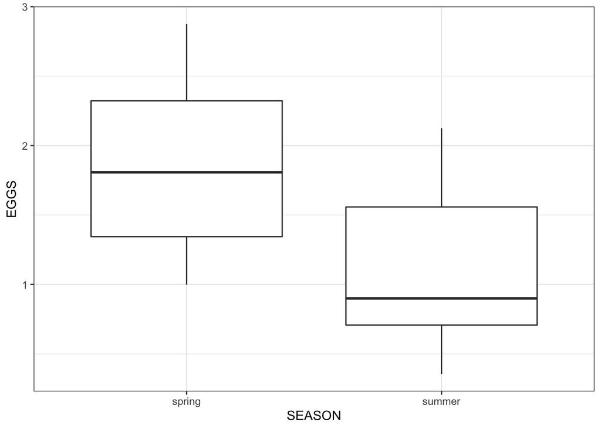

```r
ggplot(data = limpets) +
  geom_boxplot(aes(x = SEASON, y = EGGS)) +
  theme_bw()
```

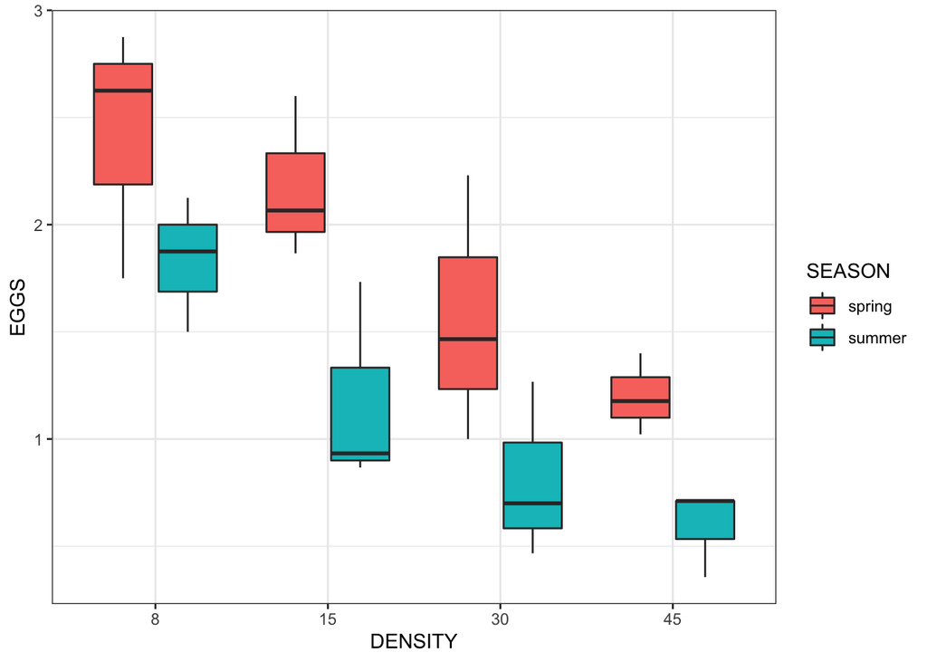

```r
ggplot(data = limpets) +
  geom_boxplot(aes(x = DENSITY, y = EGGS, fill = SEASON)) +
  theme_bw()
```

And let’s run the model.

```r
limpets_lm <- lm(data = limpets, formula = EGGS ~ SEASON * DENSITY)
summary(limpets_lm)
```

```
##
## Call:
## lm(formula = EGGS ~ SEASON * DENSITY, data = limpets)
##
## Residuals:
##     Min      1Q  Median      3Q     Max
## -0.6667 -0.2612 -0.0610  0.2292  0.6647
##
## Coefficients:
##                        Estimate Std. Error t value Pr(>|t|)
## (Intercept)             2.41667    0.24642   9.807  3.6e-08 ***
## SEASONsummer           -0.58333    0.34849  -1.674  0.11358
## DENSITY15              -0.23933    0.34849  -0.687  0.50206
## DENSITY30              -0.85133    0.34849  -2.443  0.02655 *
## DENSITY45              -1.21700    0.34849  -3.492  0.00301 **
## SEASONsummer:DENSITY15 -0.41633    0.49284  -0.845  0.41069
## SEASONsummer:DENSITY30 -0.17067    0.49284  -0.346  0.73363
## SEASONsummer:DENSITY45 -0.02367    0.49284  -0.048  0.96229
## ---
## Signif. codes:  0 '***' 0.001 '**' 0.01 '*' 0.05 '.' 0.1 ' ' 1
##
## Residual standard error: 0.4268 on 16 degrees of freedom
## Multiple R-squared:  0.749,  Adjusted R-squared:  0.6392
## F-statistic: 6.822 on 7 and 16 DF,  p-value: 0.000745
```

```r
anova(limpets_lm)
```

```
## Analysis of Variance Table
##
## Response: EGGS
##                Df Sum Sq Mean Sq F value    Pr(>F)
## SEASON          1 3.2502  3.2502 17.8419 0.0006453 ***
## DENSITY         3 5.2841  1.7614  9.6691 0.0007041 ***
## SEASON:DENSITY  3 0.1647  0.0549  0.3014 0.8239545
## Residuals      16 2.9146  0.1822
## ---
## Signif. codes:  0 '***' 0.001 '**' 0.01 '*' 0.05 '.' 0.1 ' ' 1
```

Plot the effects of Season and Density using the `allEffects` function in the `effects` package. You may need to use `install.packages` to install this package.

```r
library(effects)
```

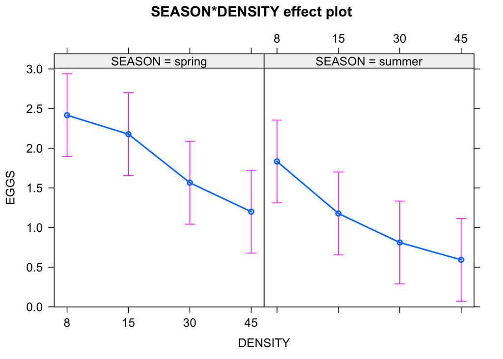

```r
plot(allEffects(limpets_lm))
```

### (Another) Example - Two factor fixed effects model

Effects of density and season on the number of eggs produced by slipper limpets.

```r
limpets1 <- read.csv(file = "https://mlammens.github.io/ENS-623-Research-Stats/data/Logan_Examples/Chapter12/Data/quinn1.csv")

head(limpets1)
```

```
##   DENSITY SEASON  EGGS
## 1       6 spring 1.167
## 2       6 spring 0.500
## 3       6 spring 1.667
## 4       6 summer 4.000
## 5       6 summer 3.830
## 6       6 summer 3.830
```

```r
summary(limpets1)
```

```
##     DENSITY      SEASON       EGGS
##  Min.   : 6   spring:9   Min.   :0.5000
##  1st Qu.: 6   summer:9   1st Qu.:0.8748
##  Median :12              Median :1.6485
##  Mean   :14              Mean   :1.9484
##  3rd Qu.:24              3rd Qu.:2.7075
##  Max.   :24              Max.   :4.0000
```

```r
limpets1$DENSITY <- factor(limpets1$DENSITY)
summary(limpets1)
```

```
##  DENSITY    SEASON       EGGS
##  6 :6    spring:9   Min.   :0.5000
##  12:6    summer:9   1st Qu.:0.8748
##  24:6               Median :1.6485
##                     Mean   :1.9484
##                     3rd Qu.:2.7075
##                     Max.   :4.0000
```

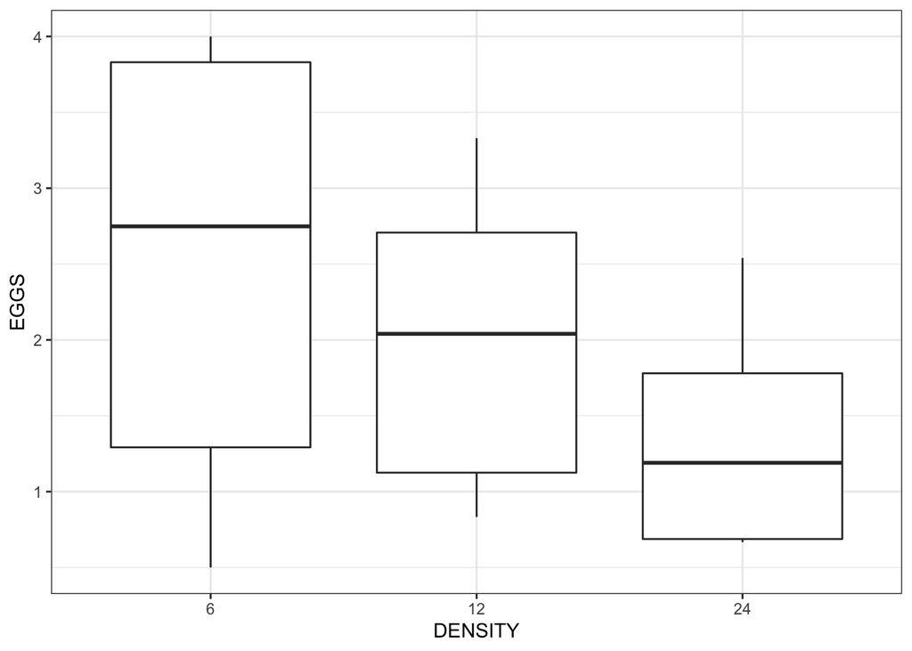

```r
ggplot(data = limpets1) +
  geom_boxplot(aes(x = DENSITY, y = EGGS)) +
  theme_bw()
```

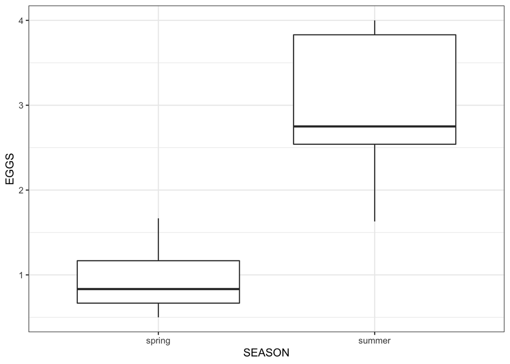

```r
ggplot(data = limpets1) +
  geom_boxplot(aes(x = SEASON, y = EGGS)) +
  theme_bw()
```

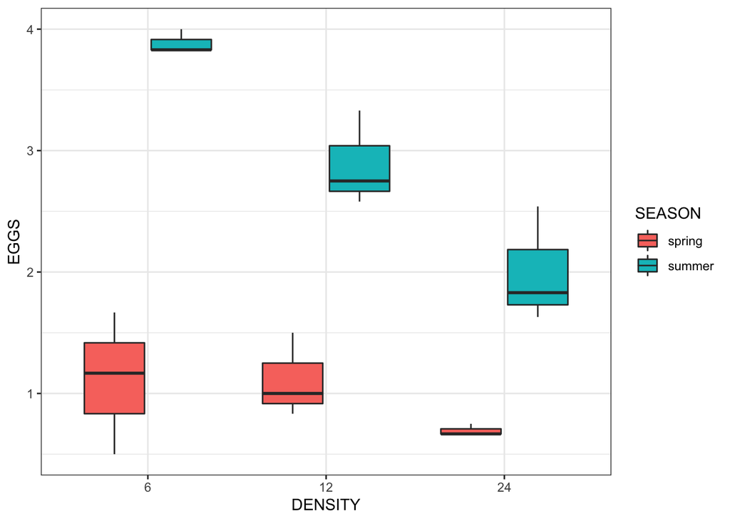

```r
ggplot(data = limpets1) +
  geom_boxplot(aes(x = DENSITY, y = EGGS, fill = SEASON)) +
  theme_bw()
```

And let’s run the model.

```r
limpets1_lm <- lm(data = limpets1, formula = EGGS ~ SEASON * DENSITY)
summary(limpets1_lm)
```

```
##
## Call:
## lm(formula = EGGS ~ SEASON * DENSITY, data = limpets1)
##
## Residuals:
##      Min       1Q   Median       3Q      Max
## -0.61133 -0.16167 -0.04217  0.09892  0.55567
##
## Coefficients:
##                          Estimate Std. Error t value Pr(>|t|)
## (Intercept)             1.1113333  0.2183934   5.089 0.000267 ***
## SEASONsummer            2.7753333  0.3088549   8.986 1.12e-06 ***
## DENSITY12              -0.0003333  0.3088549  -0.001 0.999157
## DENSITY24              -0.4166667  0.3088549  -1.349 0.202221
## SEASONsummer:DENSITY12 -0.9996667  0.4367868  -2.289 0.041029 *
## SEASONsummer:DENSITY24 -1.4700000  0.4367868  -3.365 0.005617 **
## ---
## Signif. codes:  0 '***' 0.001 '**' 0.01 '*' 0.05 '.' 0.1 ' ' 1
##
## Residual standard error: 0.3783 on 12 degrees of freedom
## Multiple R-squared:  0.9301, Adjusted R-squared:  0.9009
## F-statistic: 31.93 on 5 and 12 DF,  p-value: 1.561e-06
```

```r
anova(limpets1_lm)
```

```
## Analysis of Variance Table
##
## Response: EGGS
##                Df  Sum Sq Mean Sq F value    Pr(>F)
## SEASON          1 17.1483 17.1483 119.845 1.336e-07 ***
## DENSITY         2  4.0019  2.0010  13.984 0.0007325 ***
## SEASON:DENSITY  2  1.6907  0.8454   5.908 0.0163632 *
## Residuals      12  1.7170  0.1431
## ---
## Signif. codes:  0 '***' 0.001 '**' 0.01 '*' 0.05 '.' 0.1 ' ' 1
```

Make an effects plot

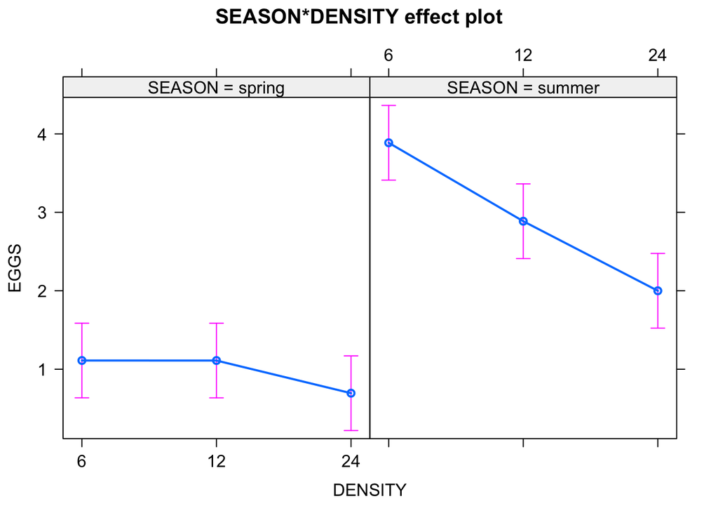

```r
plot(allEffects(limpets1_lm))
```

### Problems from unbalanced design

See Logan Fig 12.3, p. 325. The variance in a model is “explained” sequentially.

Provided there’s time, we’ll play with the models above.